# The Exercises of Week 2 - Exploratory Data Analysis

Reza Mohammadi

2022-09-15

**Full Name:** Peter Molnar (11759216)

**Online Assignments**: There is a new online-assignments at the [DataCamp](https://www.datacamp.com). This online exercise, related to data visualization in **R**, e.g., by using the [*ggplot2*](https://CRAN.R-project.org/package=ggplot2) package. These exercises are useful to prepare yourself for the computer-lab. *The online-assignments at the DataCamp are not mandatory*.

**Your task** is to answer the questions in this R-markdown file. Submit both your R-markdown (.Rmd) file and the HTML file on Canvas.

**Note:** The exercise of this week has 100 points. Besides, the Bonus part has 30 extra points.

# 1 Exploratory Data Analysis for customer churn prediction (30 points)

Customer Churn is a topic that matters to organizations of all sizes. Customer churn occurs when customers stop doing business with a company, also known as customer attrition. Churn (loss of customers to competition) is a major problem for telecom companies because it is well known that it is more expensive to acquire a new customer than to keep an existing customer. Here, we use Exploratory Data Analysis to explore the *churn* dataset. Basically, we want to visualize and identify which factors contribute to customer churn.

**Dataset**: The *churn* data set is available in the **R** package [*liver*](https://CRAN.R-project.org/package=liver). The data set contains ‘5000’ rows (customers) and 20 columns (features). The last column called *churn* is the target variable which indicates whether customers churned (left the company) or not. If you want to know more about the dataset just type `?churn` in your **R** console. You also can find more information about this dataset [here](https://rdrr.io/cran/liver/man/churn.html).

Here we need to load the following **R** packages:

- [**ggplot2**](https://CRAN.R-project.org/package=ggplot2): we use this package to visualize our data in **R**.
- [**liver**](https://CRAN.R-project.org/package=liver): the *churn* dataset is in this package.
- **GGally**: We use the `ggcorr()` function from this package.
- **psych**: We use the `pairs.panels()` function from this package.

**NOTE:** If you have not installed those two packages, you should first install them.

To load the packages:

```r
library( ggplot2 )
library( liver   )
library( GGally  )
library( psych   )
library( skimr   )
```

## 1.1 Business Understanding

Companies are interested to know who is gonna get churned so they can proactively go to the customer to provide them better services and turn customers’ decisions in the opposite direction. Companies are interested to know:

- **What** customers are we losing?
- **Why** are we losing them?
- **How** do we stop them from leaving the company?

To answer these questions here, as a practical example, we use the *churn* data set is available in the **R** package [*liver*](https://CRAN.R-project.org/package=liver).

## 1.2 Data Understanding

This dataset comes from IBM Sample Data Sets. The data set contains 5000 rows (customers) and 20 columns (features). The “churn” column is our target which indicates whether the customer churned (left the company) or not. The 20 variables are:

- `state`: Categorical, for the 51 states and the District of Columbia.
- `area.code`: Categorical.
- `account.length`: count, how long account has been active.
- `voice.plan`: Categorical, yes or no, voice mail plan.
- `voice.messages`: Count, number of voice mail messages.
- `intl.plan`: Categorical, yes or no, international plan.
- `intl.mins`: Continuous, minutes customer used service to make international calls.
- `intl.calls`: Count, total number of international calls.
- `intl.charge`: Continuous, total international charge.
- `day.mins`: Continuous, minutes customer used service during the day.
- `day.calls`: Count, total number of calls during the day.
- `day.charge`: Continuous, total charge during the day.
- `eve.mins`: Continuous, minutes customer used service during the evening.
- `eve.calls`: Count, total number of calls during the evening.
- `eve.charge`: Continuous, total charge during the evening.
- `night.mins`: Continuous, minutes customer used service during the night.
- `night.calls`: Count, total number of calls during the night.
- `night.charge`: Continuous, total charge during the night.
- `customer.calls`: Count, number of calls to customer service.
- `churn`: Categorical, yes or no. Indicator of whether the customer has left the company (yes or no).

We import the dataset in **R** as follows:

```r
data( churn ) # load the "churn" dataset
```

To see the overview of the dataset in **R** we could use the following functions:

- `str` to see a compact display of the structure of the data.
- `View` to see spreadsheet-style data.
- `head` to see the first part of the data (first 6 rows of the data).
- `summary` to see the summary of each variable.

To see the overview of the dataset in **R** we are using function `str` as follows:

```r
str( churn )   # Compactly display the structure of the data
```

```
  'data.frame': 5000 obs. of  20 variables:
   $ state         : Factor w/ 51 levels "AK","AL","AR",..: 17 36 32 36 37 2 20 25 19 50 ...
   $ area.code     : Factor w/ 3 levels "area_code_408",..: 2 2 2 1 2 3 3 2 1 2 ...
   $ account.length: int  128 107 137 84 75 118 121 147 117 141 ...
   $ voice.plan    : Factor w/ 2 levels "yes","no": 1 1 2 2 2 2 1 2 2 1 ...
   $ voice.messages: int  25 26 0 0 0 0 24 0 0 37 ...
   $ intl.plan     : Factor w/ 2 levels "yes","no": 2 2 2 1 1 1 2 1 2 1 ...
   $ intl.mins     : num  10 13.7 12.2 6.6 10.1 6.3 7.5 7.1 8.7 11.2 ...
   $ intl.calls    : int  3 3 5 7 3 6 7 6 4 5 ...
   $ intl.charge   : num  2.7 3.7 3.29 1.78 2.73 1.7 2.03 1.92 2.35 3.02 ...
   $ day.mins      : num  265 162 243 299 167 ...
   $ day.calls     : int  110 123 114 71 113 98 88 79 97 84 ...
   $ day.charge    : num  45.1 27.5 41.4 50.9 28.3 ...
   $ eve.mins      : num  197.4 195.5 121.2 61.9 148.3 ...
   $ eve.calls     : int  99 103 110 88 122 101 108 94 80 111 ...
   $ eve.charge    : num  16.78 16.62 10.3 5.26 12.61 ...
   $ night.mins    : num  245 254 163 197 187 ...
   $ night.calls   : int  91 103 104 89 121 118 118 96 90 97 ...
   $ night.charge  : num  11.01 11.45 7.32 8.86 8.41 ...
   $ customer.calls: int  1 1 0 2 3 0 3 0 1 0 ...
   $ churn         : Factor w/ 2 levels "yes","no": 2 2 2 2 2 2 2 2 2 2 ...
```

It shows that data are as a *data.frame* object in **R** with 5000 observations and 20 variables. The last column (with name *churn*) is the *target variable* that indicates whether customers churned (left the company) or not.

By using the function `summary` in **R**, we can see the summary of the dataset as follows

```r
summary( churn )
```

```
       state              area.code    account.length  voice.plan
   WV     : 158   area_code_408:1259   Min.   :  1.0   yes:1323
   MN     : 125   area_code_415:2495   1st Qu.: 73.0   no :3677
   AL     : 124   area_code_510:1246   Median :100.0
   ID     : 119                        Mean   :100.3
   VA     : 118                        3rd Qu.:127.0
   OH     : 116                        Max.   :243.0
   (Other):4240
   voice.messages   intl.plan    intl.mins       intl.calls      intl.charge
   Min.   : 0.000   yes: 473   Min.   : 0.00   Min.   : 0.000   Min.   :0.000
   1st Qu.: 0.000   no :4527   1st Qu.: 8.50   1st Qu.: 3.000   1st Qu.:2.300
   Median : 0.000              Median :10.30   Median : 4.000   Median :2.780
   Mean   : 7.755              Mean   :10.26   Mean   : 4.435   Mean   :2.771
   3rd Qu.:17.000              3rd Qu.:12.00   3rd Qu.: 6.000   3rd Qu.:3.240
   Max.   :52.000              Max.   :20.00   Max.   :20.000   Max.   :5.400

      day.mins       day.calls     day.charge       eve.mins       eve.calls
   Min.   :  0.0   Min.   :  0   Min.   : 0.00   Min.   :  0.0   Min.   :  0.0
   1st Qu.:143.7   1st Qu.: 87   1st Qu.:24.43   1st Qu.:166.4   1st Qu.: 87.0
   Median :180.1   Median :100   Median :30.62   Median :201.0   Median :100.0
   Mean   :180.3   Mean   :100   Mean   :30.65   Mean   :200.6   Mean   :100.2
   3rd Qu.:216.2   3rd Qu.:113   3rd Qu.:36.75   3rd Qu.:234.1   3rd Qu.:114.0
   Max.   :351.5   Max.   :165   Max.   :59.76   Max.   :363.7   Max.   :170.0

     eve.charge      night.mins     night.calls      night.charge
   Min.   : 0.00   Min.   :  0.0   Min.   :  0.00   Min.   : 0.000
   1st Qu.:14.14   1st Qu.:166.9   1st Qu.: 87.00   1st Qu.: 7.510
   Median :17.09   Median :200.4   Median :100.00   Median : 9.020
   Mean   :17.05   Mean   :200.4   Mean   : 99.92   Mean   : 9.018
   3rd Qu.:19.90   3rd Qu.:234.7   3rd Qu.:113.00   3rd Qu.:10.560
   Max.   :30.91   Max.   :395.0   Max.   :175.00   Max.   :17.770

   customer.calls churn
   Min.   :0.00   yes: 707
   1st Qu.:1.00   no :4293
   Median :1.00
   Mean   :1.57
   3rd Qu.:2.00
   Max.   :9.00
```

It shows the summary of all the 20 variables.

**a. For each variable in the churn dataset, specify its type.**

**Answer a**

| Variable | R Datatype | Statistical Datatype |
| --- | --- | --- |
| `state` | `Factor` | categorical - nominal |
| `area.code` | `Factor` | categorical - nominal |
| `account.length` | `int` | numerical - discrete |
| `voice.plan` | `Factor` | categorical - binary |
| `voice.messages` | `int` | numerical - discrete |
| `intl.plan` | `Factor` | categorical - binary |
| `intl.mins` | `num` | numerical - continuous |
| `intl.calls` | `int` | numerical - discrete |
| `intl.charge` | `num` | numerical - continuous |
| `day.mins` | `num` | numerical - continuous |
| `day.calls` | `int` | numerical - discrete |
| `day.charge` | `num` | numerical - continuous |
| `eve.mins` | `num` | numerical - continuous |
| `eve.calls` | `int` | numerical - discrete |
| `eve.charge` | `num` | numerical - continuous |
| `night.mins` | `num` | numerical - continuous |
| `night.calls` | `int` | numerical - discrete |
| `night.charge` | `num` | numerical - continuous |
| `customer.calls` | `int` | numerical - discrete |
| `churn` | `Factor` | categorical - binary |

**b. Based on the output of the `summary` function for the churn dataset, what is the number of customers who have an international plan (`intl.plan = "yes"`)?**

**Answer b**

```r
intl_plan_holder = length(which(churn $ intl.plan == "yes"))
intl_plan_holder
```

```
  [1] 473
```

## 1.3 Investigate the target variable *churn*

Here we report a bar plot for the target variable `churn` by using function `ggplot()` from the **R** package **ggplot2** as follows:

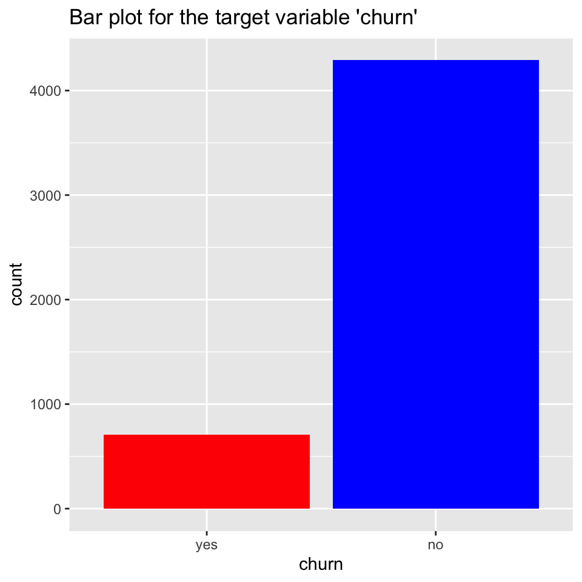

```r
ggplot( data = churn ) +
    geom_bar( aes( x = churn ), fill = c( "red", "blue" ) ) +
    labs( title = "Bar plot for the target variable 'churn'" )
```

Summary for the target variable `churn`

```r
summary( churn $ churn )
```

```
   yes   no
   707 4293
```

**Based on the above output, what is the proportion of the churner (customer churn rate)?**

**Answer**

$P(churn = no) = 4293$

$P(churn = yes) = 707$

$n = P(churn = no) + P(churn = yes) = 4293 + 707 = 5000$

$P(churn = yes) = \frac{P(churn = yes)}{n} = \frac{707}{5000} = 0.1414 = 14.14\%$

The proportion of churners is $14.14\%$.

## 1.4 Investigate variable *International Plan*

Here we first report a contingency table of International Plan (`intl.plan`) with `churn`

```r
table( churn $ churn, churn $ intl.plan, dnn = c( "Churn", "International Plan" ) )
```

```
       International Plan
  Churn  yes   no
    yes  199  508
    no   274 4019
```

Here is the above contingency table with margins

```r
addmargins( table( churn $ churn, churn $ intl.plan, dnn = c( "Churn", "International Plan" ) ) )
```

```
       International Plan
  Churn  yes   no  Sum
    yes  199  508  707
    no   274 4019 4293
    Sum  473 4527 5000
```

Bar chart for International Plan

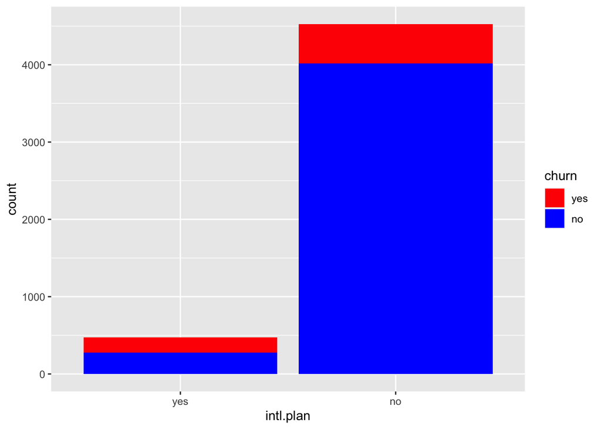

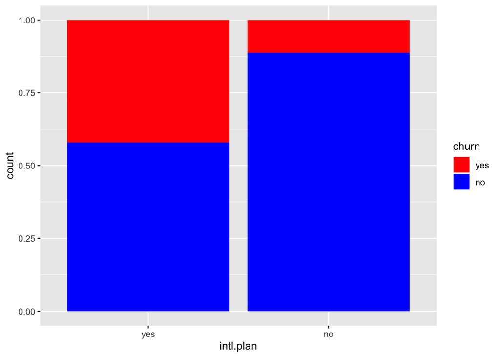

```r
ggplot( data = churn ) +
  geom_bar( aes( x = intl.plan, fill = churn ) ) +
  scale_fill_manual( values = c( "red", "blue" ) )

ggplot( data = churn ) +
  geom_bar( aes( x = intl.plan, fill = churn ), position = "fill" ) +
  scale_fill_manual( values = c( "red", "blue" ) )
```

**What would be your interpretation of the above plots?**

**Answer**

The right chart is the standardised version of the bar chart on the left. The standardised chart’s y-axis ranges between 0 and 1, and it shows the proportions of churners in each `intl.plan` category. This chart allows for more precision; we read that approximately 42% of international plan holders change to a different company, while this number is around 11% for those not having an international plan.

Conclusively, international plan holders churn rate is about four times higher than for non subscribers. The variable in question may bear with explanatory power, hence it would not come as a surprise if the data mining algorithm would use `intl.plan` in the prediction model.

## 1.5 Investigate variable “*voice mail plan*”

Make a table for counts of Churn and Voice Mail Plan

```r
addmargins(table( churn $ churn, churn $ voice.plan, dnn = c( "Churn", "Voice Mail Plan" ) ))
```

```
       Voice Mail Plan
  Churn  yes   no  Sum
    yes  102  605  707
    no  1221 3072 4293
    Sum 1323 3677 5000
```

Bar chart for Voice Mail Plan

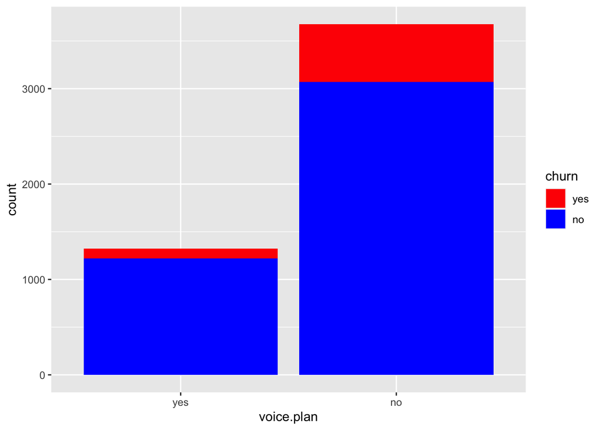

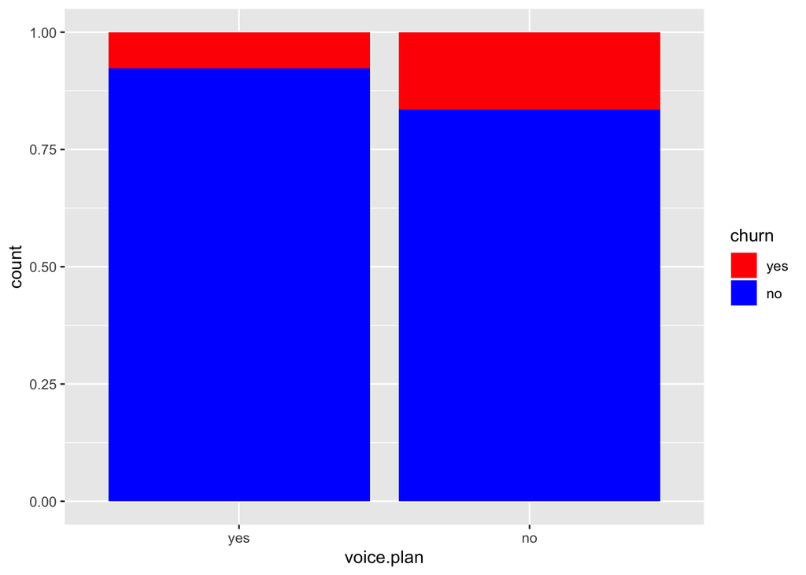

```r
ggplot( data = churn ) +
  geom_bar( aes( x = voice.plan, fill = churn ) ) +
  scale_fill_manual( values = c( "red", "blue" ) )

ggplot( data = churn ) +
  geom_bar( aes( x = voice.plan, fill = churn ), position = "fill" ) +
  scale_fill_manual( values = c( "red", "blue" ) )
```

**What would be your interpretation of the above plots?**

**Answer**

The left plot depicts a barchart for `voice.plan`, with `churn` overlay, groupped by `voice.plan` categories. Those of voice plan holders represent themselves with 1300 customers, while those of non-holders with about 3700 customers.

The right plot is a standardised bar chart, and shows that approximately 8% of voice mail plan holders churn. For those who did not opt for voice mail plan, the churn rate is roughly twice as much, 16%.

Conclusively, churn rate is higher amongst customers who do not have voice mail plan, than for those who do have. `voice.plan` may have some explanation for the 14.14% churn rate, and hence we should expect that the data mining algorithm will include it in prediction model.

## 1.6 Investigate variable “*customer service calls*”

Here, we are interested to investigate the relationship between variable “*customer service calls*” and the target variable “*churn*”. First, we report the histogram of the variable “*customer service calls*” by using function `ggplot` as follows

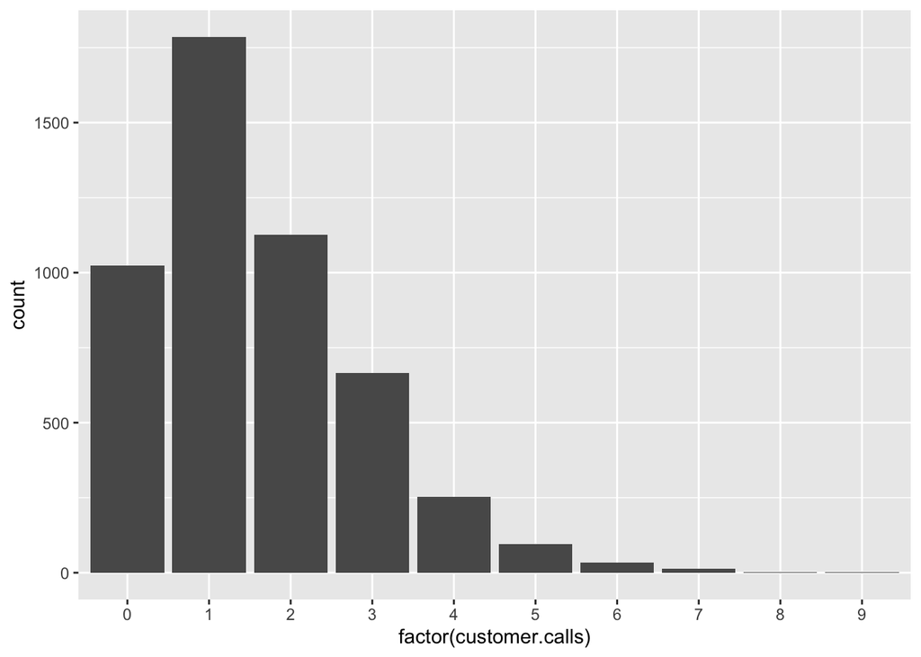

```r
ggplot( data = churn ) +
  geom_bar( aes( x = factor( customer.calls ) ) )
```

To see the relationship between variable “*customer service calls*” and the target variable “*churn*”, we report the histogram of the variable “*customer service calls*” including “churn” overlay as follows

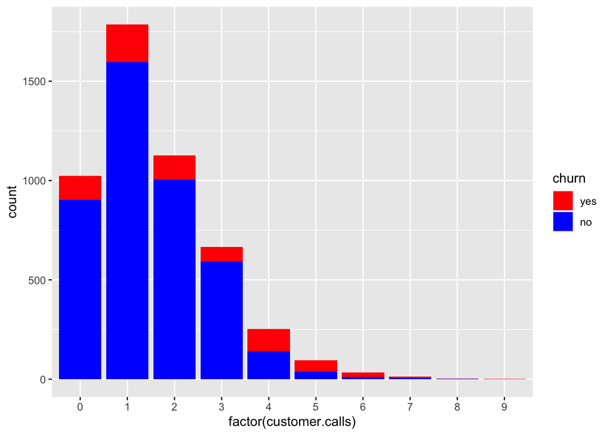

```r
ggplot( data = churn ) +
  geom_bar( aes( x = factor( customer.calls ), fill = churn ), position = "stack" ) +
  scale_fill_manual( values = c( "red", "blue" ) )
```

We also report the *Normalized* histogram of variable “*customer service calls*” including “churn” overlay as follow

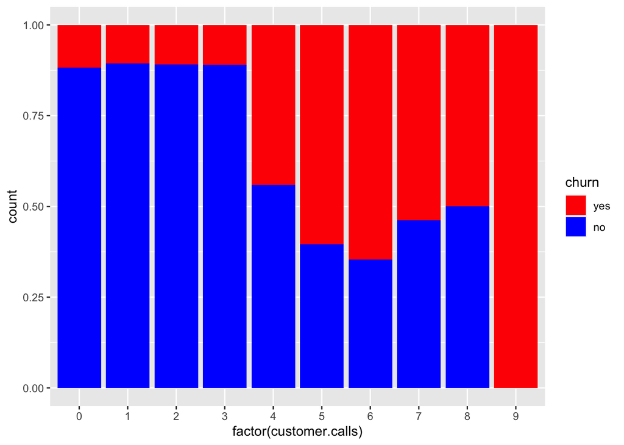

```r
ggplot( data = churn ) +
  geom_bar( aes( x = factor( customer.calls ), fill = churn ), position = "fill" ) +
  scale_fill_manual( values = c( "red", "blue" ) )
```

**What would be your interpretation of the above plots?**

**Answer**

The first plot is a histogram of `customer.calls`, and it is positively skewed, whit a mean of 1.5704 call(s). The skewness of the data may be explained by that the majority of customers who contacts the customer service desk have their matter solved within one call, and hence there is no need for further calls.

The second plot is similar to the first histogram, however, it adds `churn` overlay. Since it is challenging to read the proportions of the histogram we turn to the standardised histogram, that is the last plot.

The standardised histogram depicts the proportions of churners vs non-churners for each histogram bar. We observe that that churn rate is fairly stable at around 11% for customers who had less than 3 customer service calls. The churn rate, however, at least quadruples for those contacting the customer service desk at least 4 times. It seems, that customers tolerance or satisfaction drops significantly as soon as they need to call at least 4 times the customer service.

It is worth to note, that the standardised and non-standardised plots must be used together, otherwise it may lead to misleading observations. Such as, if we did not take into account the non-stardardised histogram, then we would conclude that customers calling the service desk 9 times churn wiht certainty. However, this would be misleading, since there are only just a handful of 9 count observations.

Given the strong graphical evidence of predictive importance, it is expected that the data mining algorithm will include `service.calls` in the model.

## 1.7 Investigate variable “*Day Minutes*”

Here, we are interested to investigate the relationship between variable Day Minutes and the target variable *Churn*. First, we report the “Normalized” histogram of Day Minutes including Churn overlay:

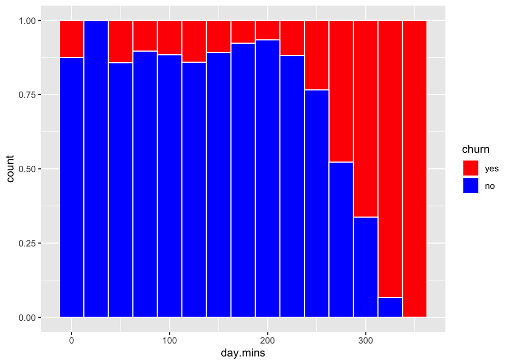

```r
ggplot( data = churn ) +
  geom_histogram( aes( x = day.mins, fill = churn ), position = "fill", binwidth = 25, color="white" ) +
  scale_fill_manual( values = c( "red", "blue" ) )
```

Another way to see the relationship between variable Day Minutes and the target variable *churn*, would be by using the boxplot as follows

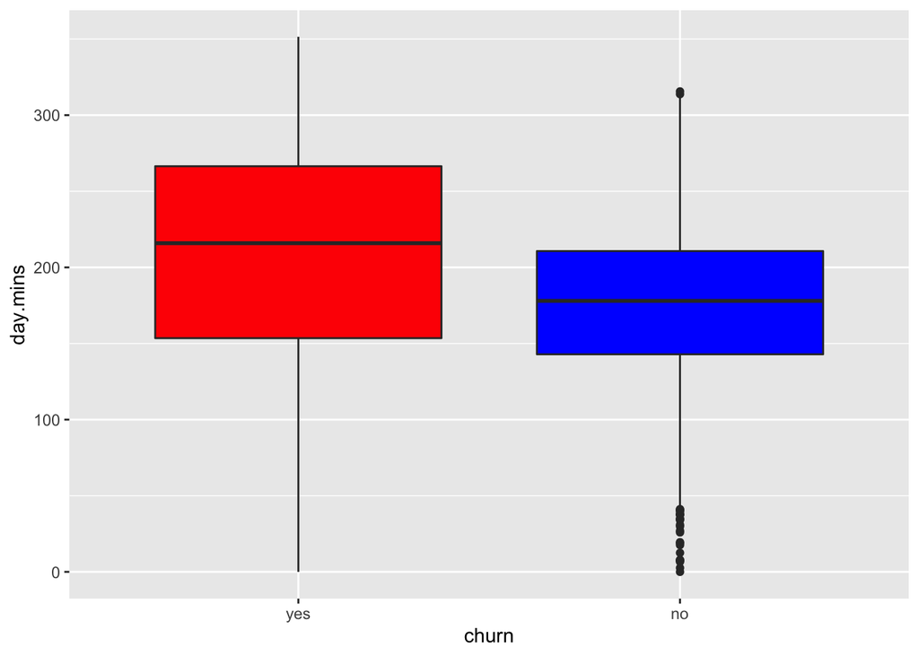

```r
ggplot( data = churn ) +
  geom_boxplot( aes( x = churn, y = day.mins ), fill = c( "red", "blue" ) )
```

**What would be your interpretation of the above boxplot?**

**Answer**

The above boxplots depict the locality, spread and skewness of `day.mins` grouped by `churn` categories.

To allow for a more precise analysis, we need to plot the data as frequency density plot; the below code performs that.

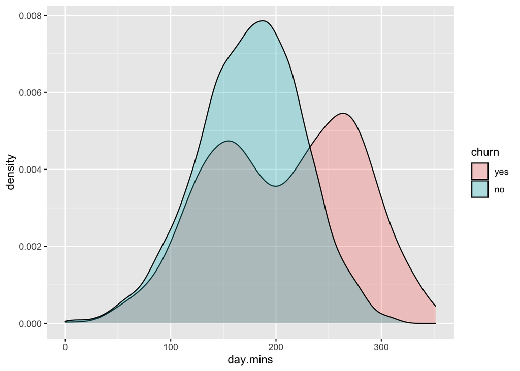

```r
ggplot( data = churn) +
  geom_density( aes( x = day.mins, fill = churn ), alpha = 0.3)
```

**Comparison of skewness:** `day.mins` for churners is skewed to the left - churners spend more on phone calls, than non churners.

**Comparison of potential outliers:** `day.mins`’s whisker spreads from the minima of the data to the maxima of it, and hence it does not have any outliers, or unusual values. This cannot be stated for non-churners, since they have potential outliers beyond the lower and upper whiskers.

`day.minutes` seem to hold relevant information, and therefore we should expect the data mining algorithm to select this variable into the model.

## 1.8 Investigate variable “*International Calls*”

Here, we are interested to investigate the relationship between variable International Calls and the target variable `churn`. First, we report the histogram of the variable International Calls as follows:

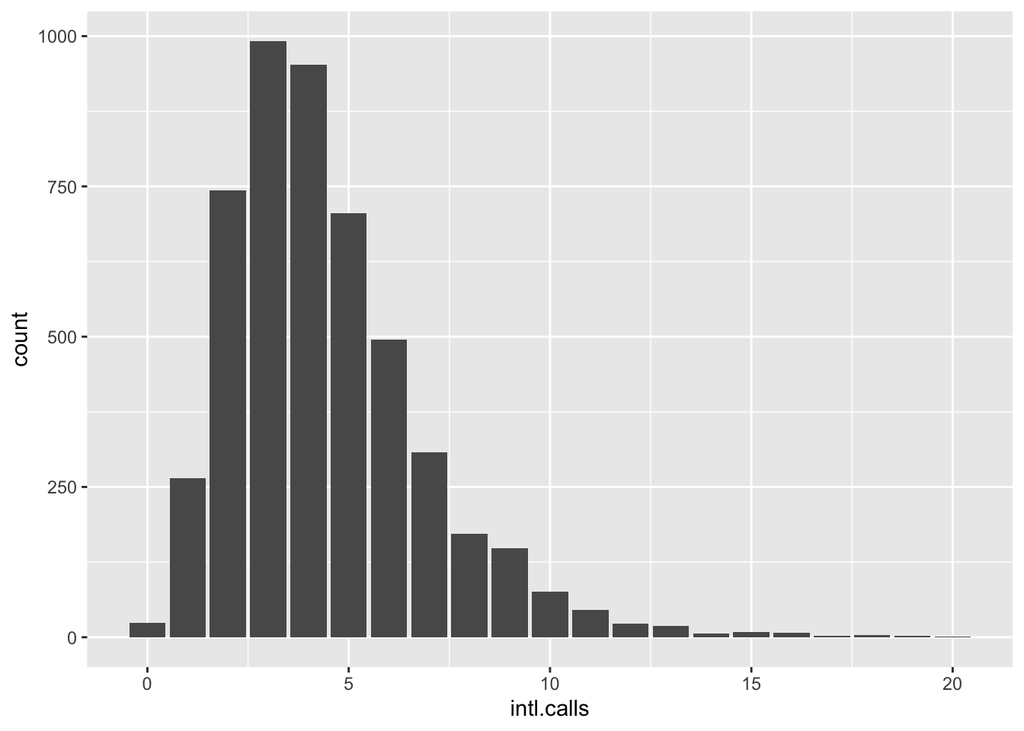

```r
ggplot( data = churn ) +
  geom_bar( aes( x = intl.calls ) )
```

To see the relationship between variable International Calls and the target variable *churn*, we report the histogram of variable International Calls including Churn overlay as follow

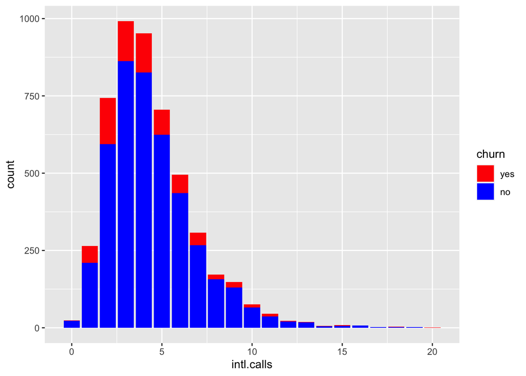

```r
ggplot( data = churn ) +
  geom_bar( aes( x = intl.calls, fill = churn ), position = "stack" ) +
  scale_fill_manual( values = c( "red", "blue" ) )
```

We also report the *Normalized* histogram of variable International Calls including Churn overlay as follow

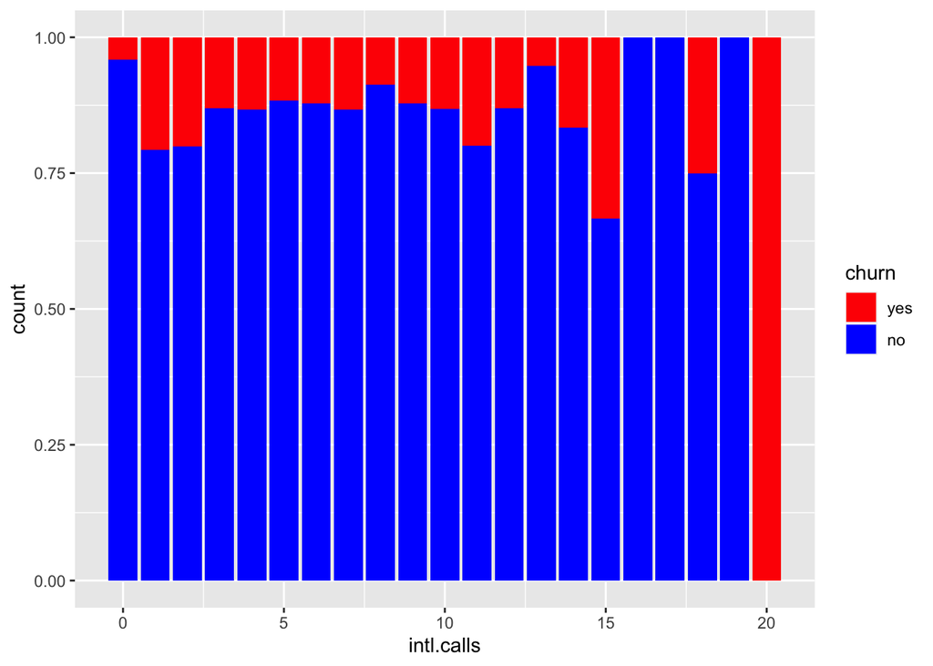

```r
ggplot( data = churn ) +
  geom_bar( aes( x = intl.calls, fill = churn ), position = "fill" ) +
  scale_fill_manual( values = c( "red", "blue" ) )
```

To see the relationship between variable International Calls and the target variable *churn*, we report the boxplot as follow

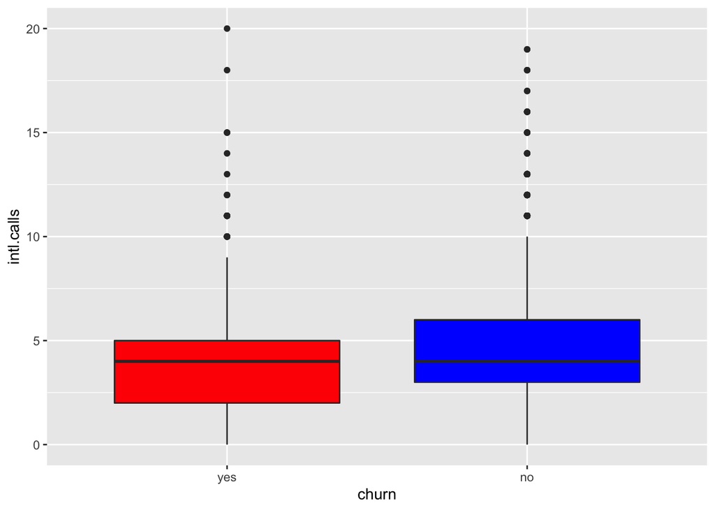

```r
ggplot( data = churn ) +
  geom_boxplot( aes( x = churn, y = intl.calls ), fill = c( "red", "blue" ) )
```

**What would be your interpretation of the above boxplot?**

**Answer**

The boxplot on the left represents churners, and the right non-churners. Both non- and churners are positively skewed, and have their medians at approximately 4 calls.

Both plots report outliers above approximately 10 calls. The boxplot, however, does not indicate strong evidence of the predictive importance of international calls.

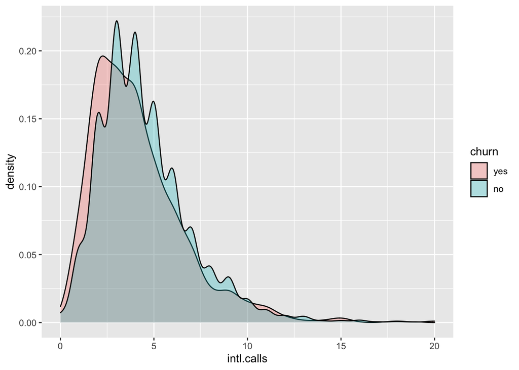

```r
ggplot( data = churn) +
  geom_density( aes( x = intl.calls, fill = churn ), alpha = 0.3)
```

## 1.9 Detect Correlated Variables

To visualize the correlation matrix between the “day.mins”, “Day.Calls”, “Day.Charge”, “Eve.Mins”, “Eve.Calls”, “Eve.Charge”, “Night.Mins”, “Night.Calls”, and “Night.Charge”, we could use the `ggcorr` function as follows

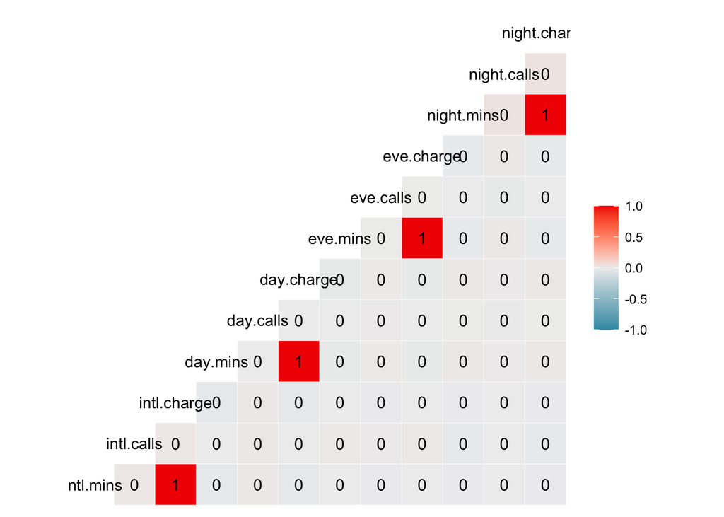

```r
variable_list = c( "intl.mins",  "intl.calls",  "intl.charge",
                   "day.mins",   "day.calls",   "day.charge",
                   "eve.mins",   "eve.calls",   "eve.charge",
                   "night.mins", "night.calls", "night.charge" )

ggcorr( data = churn[ , variable_list ], label = TRUE )
```

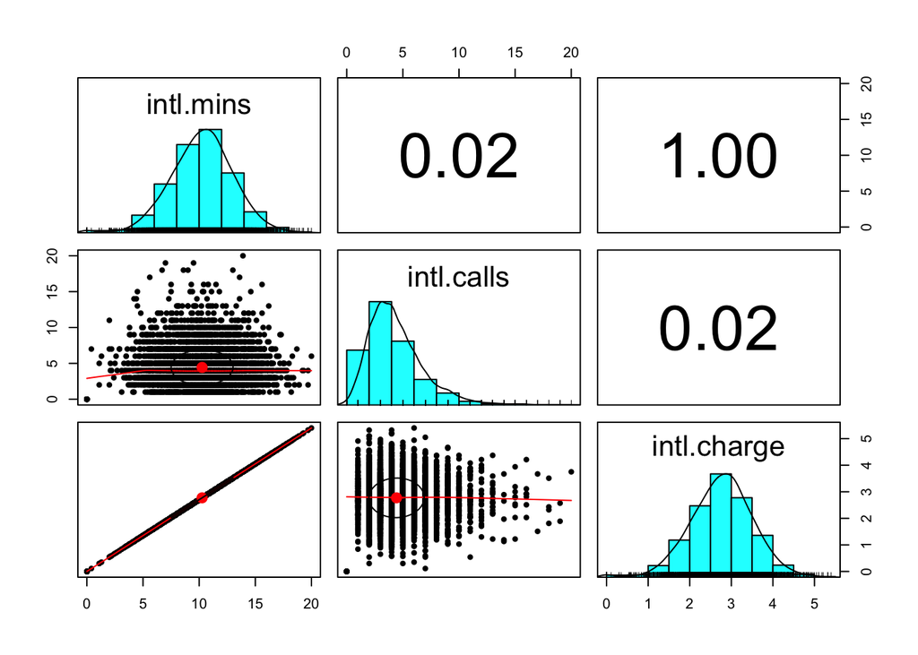

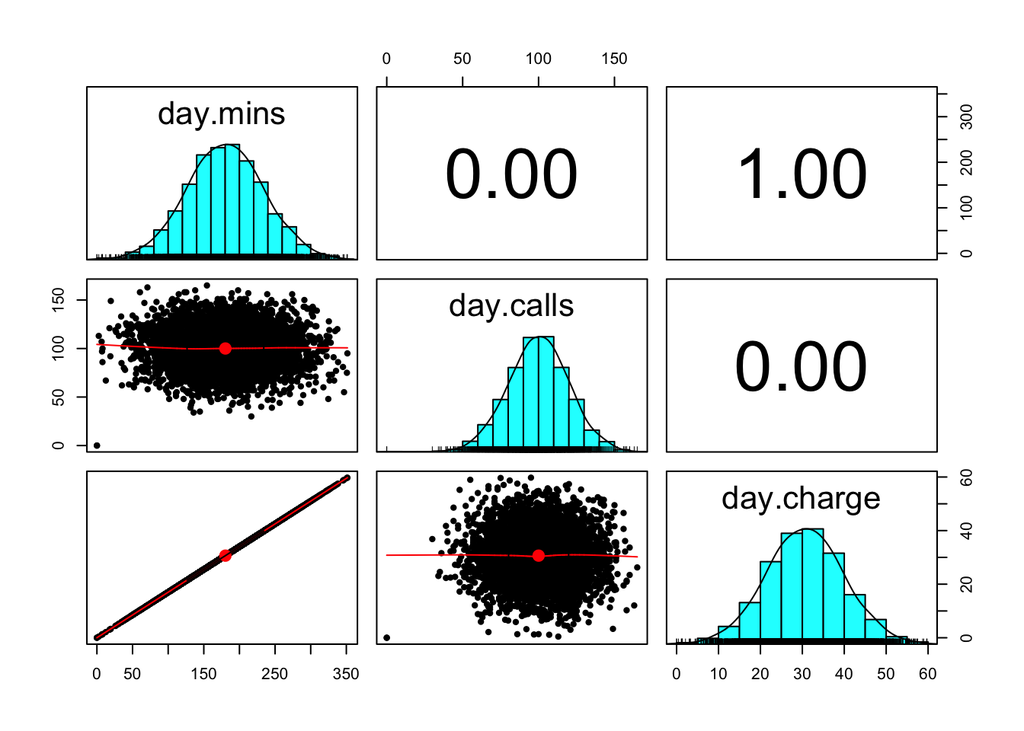

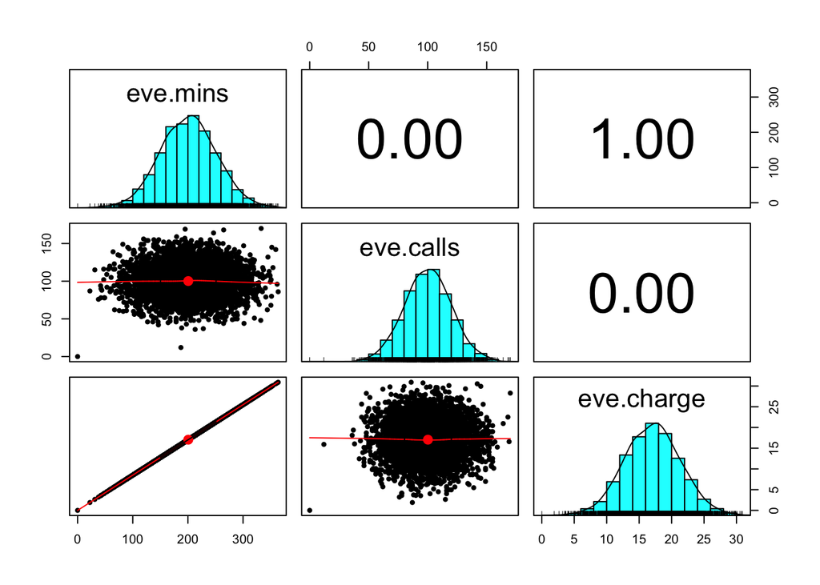

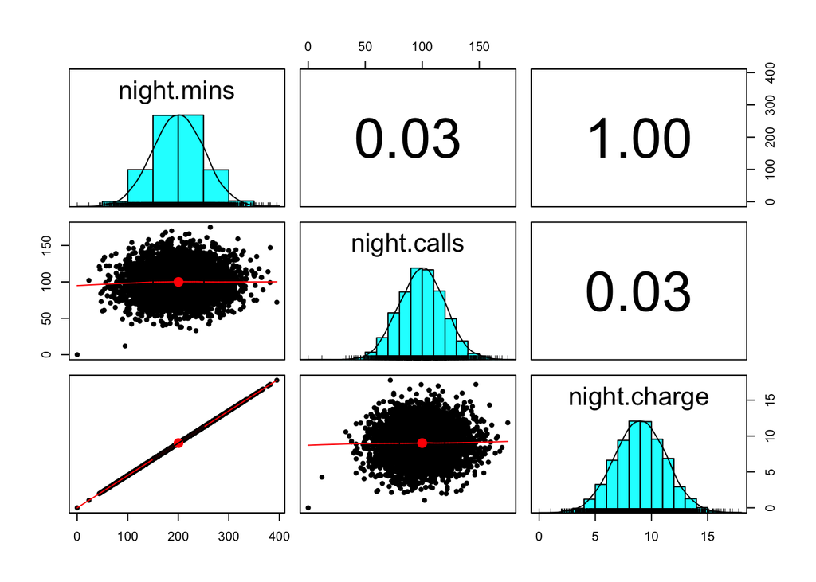

```r
pairs.panels( churn[ , c( "intl.mins", "intl.calls", "intl.charge" ) ] )

pairs.panels( churn[ , c( "day.mins", "day.calls", "day.charge" ) ] )

pairs.panels( churn[ , c( "eve.mins", "eve.calls", "eve.charge" ) ] )

pairs.panels( churn[ , c( "night.mins", "night.calls", "night.charge" ) ] )
```

**What would be your interpretation of the above correlation matrix plots?**

**Answer**

From the above correlation matrix we see that there are 4 problematic variable that shows perfect correlation with another variable.

Namely, `night.charge` is perfectly linearly correlated with `night.mins`, which does not come as surprise, since the former is a function of `night.mins`. The same holds true for `eve.mins` and `eve.charge`, `day.mins` and `day.charge`, `intl.mins` and `intl.charge`.

# 2 Exploratory Data Analysis for Bank direct marketing dataset (70 points)

In this part, we want to use Exploratory Data Analysis to explore the *bank* dataset that is available in the **R** package [**liver**](https://CRAN.R-project.org/package=liver). You could find more information about the *bank* dataset at the following link on pages 4-5: [manual of the liver package](https://cran.r-project.org/web/packages/liver/liver.pdf); Or [here](https://rdrr.io/cran/liver/man/bank.html).

## 2.1 Business Understanding

Find the best strategies to improve for the next marketing campaign. How can the financial institution have greater effectiveness for future marketing campaigns? To make a data-driven decision, we need to analyze the last marketing campaign the bank performed and identify the patterns that will help us find conclusions to develop future strategies.

### 2.1.1 Bank direct marketing info

Two main approaches for enterprises to promote products/services are:

- *mass campaigns*: targeting general indiscriminate public,
- *directed marketing*, targeting a specific set of contacts.

In general, positive responses to mass campaigns are typically very low (less than 1%). On the other hand, direct marketing focuses on targets that are keener to that specific product/service, making this kind of campaign more effective. However, direct marketing has some drawbacks, for instance, it may trigger a negative attitude towards banks due to the intrusion of privacy.

Banks are interested to increase financial assets. One strategy is to offer attractive long-term deposit applications with good interest rates, in particular, by using directed marketing campaigns. Also, the same drivers are pressing for a reduction in costs and time. Thus, there is a need for an improvement in efficiency: lesser contacts should be done, but an approximate number of successes (clients subscribing to the deposit) should be kept.

### 2.1.2 What is a Term Deposit?

A Term Deposit is a deposit that a bank or a financial institution offers with a fixed rate (often better than just opening a deposit account), in which your money will be returned at a specific maturity time. For more information with regards to Term Deposits please check [here](https://www.investopedia.com/terms/t/termdeposit.asp).

## 2.2 Data Undestanding

The *bank* dataset is related to direct marketing campaigns of a Portuguese banking institution. You can find more information related to this dataset at: https://rdrr.io/cran/liver/man/bank.html

The marketing campaigns were based on phone calls. Often, more than one contact (to the same client) was required, to access if the product (bank term deposit) would be (or not) subscribed. The classification goal is to predict if the client will subscribe to a term deposit (variable deposit).

We import the *bank* dataset:

```r
data( bank )
```

We can see the structure of the dataset by using the `str` function:

```r
str( bank )
```

```
  'data.frame': 4521 obs. of  17 variables:
   $ age      : int  30 33 35 30 59 35 36 39 41 43 ...
   $ job      : Factor w/ 12 levels "admin.","blue-collar",..: 11 8 5 5 2 5 7 10 3 8 ...
   $ marital  : Factor w/ 3 levels "divorced","married",..: 2 2 3 2 2 3 2 2 2 2 ...
   $ education: Factor w/ 4 levels "primary","secondary",..: 1 2 3 3 2 3 3 2 3 1 ...
   $ default  : Factor w/ 2 levels "no","yes": 1 1 1 1 1 1 1 1 1 1 ...
   $ balance  : int  1787 4789 1350 1476 0 747 307 147 221 -88 ...
   $ housing  : Factor w/ 2 levels "no","yes": 1 2 2 2 2 1 2 2 2 2 ...
   $ loan     : Factor w/ 2 levels "no","yes": 1 2 1 2 1 1 1 1 1 2 ...
   $ contact  : Factor w/ 3 levels "cellular","telephone",..: 1 1 1 3 3 1 1 1 3 1 ...
   $ day      : int  19 11 16 3 5 23 14 6 14 17 ...
   $ month    : Factor w/ 12 levels "apr","aug","dec",..: 11 9 1 7 9 4 9 9 9 1 ...
   $ duration : int  79 220 185 199 226 141 341 151 57 313 ...
   $ campaign : int  1 1 1 4 1 2 1 2 2 1 ...
   $ pdays    : int  -1 339 330 -1 -1 176 330 -1 -1 147 ...
   $ previous : int  0 4 1 0 0 3 2 0 0 2 ...
   $ poutcome : Factor w/ 4 levels "failure","other",..: 4 1 1 4 4 1 2 4 4 1 ...
   $ deposit  : Factor w/ 2 levels "no","yes": 1 1 1 1 1 1 1 1 1 1 ...
```

It shows that the *bank* dataset as a `data.frame` has 17 variables and 4521 observations. The dataset has 16 predictors along with the target variable `deposit` which is a binary variable with 2 levels “yes” and “no”. The variables in this dataset are:

- `age`: numeric.
- `job`: type of job; categorical: “admin.”, “unknown”, “unemployed”, “management”, “housemaid”, “entrepreneur”, “student”, “blue-collar,”self-employed”, “retired”, “technician”, “services”.
- `marital`: marital status; categorical: “married”, “divorced”, “single”; note: “divorced” means divorced or widowed.
- `education`: categorical: “secondary”, “primary”, “tertiary”, “unknown”.
- `default`: has credit in default?; binary: “yes”,“no”.
- `balance`: average yearly balance, in euros; numeric.
- `housing`: has housing loan? binary: “yes”, “no”.
- `loan`: has personal loan? binary: “yes”, “no”.

Related with the last contact of the current campaign:

- `contact`: contact: contact communication type; categorical: “unknown”,“telephone”,“cellular”.
- `day`: last contact day of the month; numeric.
- `month`: last contact month of year; categorical: “jan”, “feb”, “mar”, …, “nov”, “dec”.
- `duration`: last contact duration, in seconds; numeric.

Other attributes:

- `campaign`: number of contacts performed during this campaign and for this client; numeric, includes last contact.
- `pdays`: number of days that passed by after the client was last contacted from a previous campaign; numeric, -1 means client was not previously contacted.
- `previous`: number of contacts performed before this campaign and for this client; numeric.
- `poutcome`: outcome of the previous marketing campaign; categorical: “success”, “failure”, “unknown”, “other”.

Target variable:

- `deposit`: Indicator of whether the client subscribed a term deposit; binary: “yes” or “no”.

**Following Part 1, first, report the summary of the dataset then apply the Exploratory Data Analysis.**

**Answer**

```r
summary(bank)
```

```
        age                 job          marital         education    default
   Min.   :19.00   management :969   divorced: 528   primary  : 678   no :4445
   1st Qu.:33.00   blue-collar:946   married :2797   secondary:2306   yes:  76
   Median :39.00   technician :768   single  :1196   tertiary :1350
   Mean   :41.17   admin.     :478                   unknown  : 187
   3rd Qu.:49.00   services   :417
   Max.   :87.00   retired    :230
                   (Other)    :713
      balance      housing     loan           contact          day
   Min.   :-3313   no :1962   no :3830   cellular :2896   Min.   : 1.00
   1st Qu.:   69   yes:2559   yes: 691   telephone: 301   1st Qu.: 9.00
   Median :  444                         unknown  :1324   Median :16.00
   Mean   : 1423                                          Mean   :15.92
   3rd Qu.: 1480                                          3rd Qu.:21.00
   Max.   :71188                                          Max.   :31.00

       month         duration       campaign          pdays
   may    :1398   Min.   :   4   Min.   : 1.000   Min.   : -1.00
   jul    : 706   1st Qu.: 104   1st Qu.: 1.000   1st Qu.: -1.00
   aug    : 633   Median : 185   Median : 2.000   Median : -1.00
   jun    : 531   Mean   : 264   Mean   : 2.794   Mean   : 39.77
   nov    : 389   3rd Qu.: 329   3rd Qu.: 3.000   3rd Qu.: -1.00
   apr    : 293   Max.   :3025   Max.   :50.000   Max.   :871.00
   (Other): 571
      previous          poutcome    deposit
   Min.   : 0.0000   failure: 490   no :4000
   1st Qu.: 0.0000   other  : 197   yes: 521
   Median : 0.0000   success: 129
   Mean   : 0.5426   unknown:3705
   3rd Qu.: 0.0000
   Max.   :25.0000
```

```r
skim(bank)
```

Data summary

| Name | bank |
| --- | --- |
| Number of rows | 4521 |
| Number of columns | 17 |
| _______________________ |  |
| Column type frequency: |  |
| factor | 10 |
| numeric | 7 |
| ________________________ |  |
| Group variables | None |

**Variable type: factor**

| skim_variable | n_missing | complete_rate | ordered | n_unique | top_counts |
| --- | --- | --- | --- | --- | --- |
| job | 0 | 1 | FALSE | 12 | man: 969, blu: 946, tec: 768, adm: 478 |
| marital | 0 | 1 | FALSE | 3 | mar: 2797, sin: 1196, div: 528 |
| education | 0 | 1 | FALSE | 4 | sec: 2306, ter: 1350, pri: 678, unk: 187 |
| default | 0 | 1 | FALSE | 2 | no: 4445, yes: 76 |
| housing | 0 | 1 | FALSE | 2 | yes: 2559, no: 1962 |
| loan | 0 | 1 | FALSE | 2 | no: 3830, yes: 691 |
| contact | 0 | 1 | FALSE | 3 | cel: 2896, unk: 1324, tel: 301 |
| month | 0 | 1 | FALSE | 12 | may: 1398, jul: 706, aug: 633, jun: 531 |
| poutcome | 0 | 1 | FALSE | 4 | unk: 3705, fai: 490, oth: 197, suc: 129 |
| deposit | 0 | 1 | FALSE | 2 | no: 4000, yes: 521 |

**Variable type: numeric**

| skim_variable | n_missing | complete_rate | mean | sd | p0 | p25 | p50 | p75 | p100 | hist |
| --- | --- | --- | --- | --- | --- | --- | --- | --- | --- | --- |
| age | 0 | 1 | 41.17 | 10.58 | 19 | 33 | 39 | 49 | 87 | ▅▇▅▁▁ |
| balance | 0 | 1 | 1422.66 | 3009.64 | -3313 | 69 | 444 | 1480 | 71188 | ▇▁▁▁▁ |
| day | 0 | 1 | 15.92 | 8.25 | 1 | 9 | 16 | 21 | 31 | ▆▆▇▅▆ |
| duration | 0 | 1 | 263.96 | 259.86 | 4 | 104 | 185 | 329 | 3025 | ▇▁▁▁▁ |
| campaign | 0 | 1 | 2.79 | 3.11 | 1 | 1 | 2 | 3 | 50 | ▇▁▁▁▁ |
| pdays | 0 | 1 | 39.77 | 100.12 | -1 | -1 | -1 | -1 | 871 | ▇▁▁▁▁ |
| previous | 0 | 1 | 0.54 | 1.69 | 0 | 0 | 0 | 0 | 25 | ▇▁▁▁▁ |

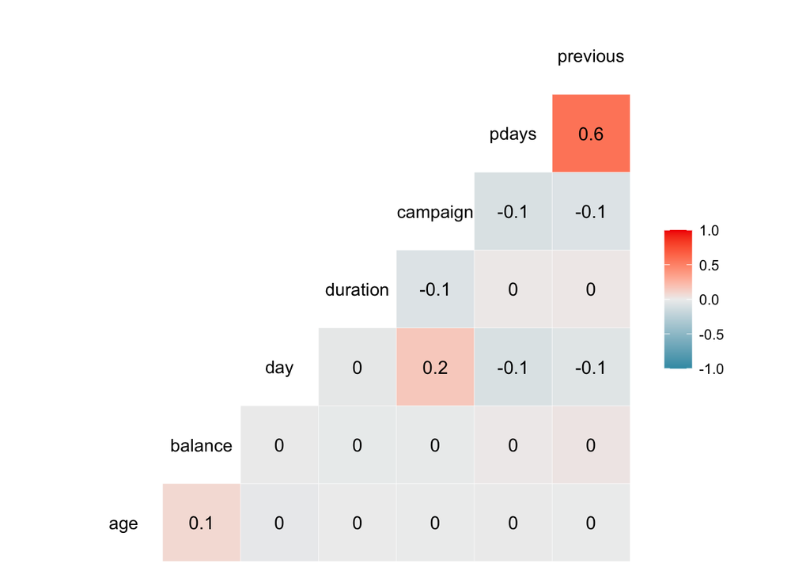

```r
variable_list = c( "age", "job", "marital", "education", "default", "balance",
                   "housing", "loan", "contact", "day", "month",  "duration",
                   "campaign", "pdays", "previous", "poutcome", "deposit")

ggcorr( data = bank[ , variable_list ], label = TRUE )
```

# 3 **Bonus**: Exploratory Data Analysis for your own dataset (30 points)

In this part, you could apply Exploratory Data Analysis to explore your own dataset. You could follow the same steps as in part 1 (above) of these exercises.